# DATA-413/613 Homework: Tidy Text 1

Author

Te-Jou Hou (Carol)

Published

November 19, 2024

# 1 Sentiment Analysis

1. Use the steps below to download the following two complete works from the early 20<sup>th</sup> century from Project Gutenberg:
- Upton Sinclair: “*The Jungle*” (1906)
- W.E.B. Du Bois: “*The Quest of the Silver Fleece*” (1911).

**Important**

- You will need the development version of {gutenberger} 0.2.4.9000. (see [Issue 47](https://github.com/ropensci/gutenbergr/issues/47))
- This is available from the GitHUb at https://github.com/ropensci/gutenbergr.
- You can use any of several packages to install the development version (not the CRAN version):
  - `pak::pak("ropensci/gutenbergr")`
  - `remotes::install_github("ropensci/gutenbergr")`
  - `devtools::install_github("ropensci/gutenbergr")`
- Find and show the author IDs - you can show others like them.

```r
library(gutenbergr)
library(tidyverse)

gutenberg_authors[(str_detect(gutenberg_authors$author, "Sinclair")), ]|>
  select(gutenberg_author_id, author)
```

```
# A tibble: 16 × 2
   gutenberg_author_id author
                 <int> <chr>
 1                  88 Sinclair, Upton
 2                 278 Lewis, Sinclair
 3                3004 Sinclair, May
 4                3891 Sinclair, Bertrand W.
 5                6083 Caithness, James Sinclair, 14th earl of
 6               36057 Sinclair, Catherine
 7               36520 Rohde, Eleanour Sinclair
 8               43078 Kennedy, Sinclair
 9               44745 Ford, Clyde S. (Clyde Sinclair)
10               47060 Sinclair, John
11               49522 Wellby, M. S. (Montagu Sinclair)
12               52033 Sinclair, Angus
13               52266 Drago, Harry Sinclair
14               53992 Gluck, Sinclair
15               55571 Sinclair, George
16               56520 Sinclair, F. G. (Frederick Granville)
```

```r
gutenberg_authors[(str_detect(gutenberg_authors$author, "Du Bois")), ]|>
  select(gutenberg_author_id, author)
```

```
# A tibble: 4 × 2
  gutenberg_author_id author
                <int> <chr>
1                 226 Du Bois, W. E. B. (William Edward Burghardt)
2                7579 Du Boisgobey, Fortuné
3               34882 Du Bois, Louis
4               44429 Du Bois, Gaylord
```

- Find and show their works to show the `gutenberg_id` - you can show other works as well.

```r
gutenberg_works() |>
  filter(gutenberg_author_id %in% c(88, 226))|>
  select(gutenberg_id, title, gutenberg_author_id, author)
```

```
# A tibble: 54 × 4
   gutenberg_id title                                 gutenberg_author_id author
          <int> <chr>                                               <int> <chr>
 1          140 "The Jungle"                                           88 Sincl…
 2          408 "The Souls of Black Folk"                             226 Du Bo…
 3         1157 "Damaged Goods\r\nThe great play \"L…                  88 Sincl…
 4         1558 "The Profits of Religion: An Essay i…                  88 Sincl…
 5         3301 "The Naturewoman"                                      88 Sincl…
 6         3302 "The Second-Story Man"                                 88 Sincl…
 7         3303 "Prince Hagen"                                         88 Sincl…
 8         3304 "The Machine"                                          88 Sincl…
 9         4923 "King Midas: a Romance"                                88 Sincl…
10         5421 "The Metropolis"                                       88 Sincl…
# ℹ 44 more rows
```

- Use the `gutenberg_ids` to download the books into separate tibbles.

```r
jungle <- gutenberg_download(gutenberg_id = 140)

QSF <- gutenberg_download(gutenberg_id = 15265)
```

2. Write a single function, `tidydoc()`, to take an argument of a downloaded book tibble and return it in tidy text format after doing the following.
- Add line and chapter numbers as variables before removing any lines.
- Unnest tokens at the word level.
- Remove any Project Gutenberg formatting so only the words remain.
  - **If you wind up with fewer words**, look closely for the use of *single right quote* “‘“vs apostrophe”’”in Jungle.
  - They are different Unicode characters. You should add to the regex for `str_extract()`.
  - To create a single right quote on a mac, use `Shift+ Option + }` to get ’.
  - To create a single right quote on a windows keyboard use `ALT + 8217`. See [Right Single Quotation Mark](https://www.hotsymbol.com/symbol/right-single-quotation-mark).
- Remove any stop_words.
- Filter out any `NA`s.
- Remove any front matter (words before Chapter 1).

```r
library(tidytext)

tidydoc <- function(book_tibble) {

 book_tibble |>
    mutate(
      linenumber = row_number(),
      chapter = cumsum(str_detect(text, regex(
        "^chapter [\\divxlc]|^_(?!Contents)(?!Note)[:alpha:]+-?[:alpha:]*_$",
                                        ignore_case = TRUE)))) |>
    unnest_tokens(word, text) |>
    mutate(word = str_extract(word, "[a-z’']+")) |>
    anti_join(stop_words, by = "word") |>
    filter(!is.na(word)) |>
    filter(chapter > 0) ->tidy_book

  return(tidy_book)
}
```

Explain the following regex example for finding chapter numbers.

- `c_pattern <- regex("(^chapter [\\divxlc]|^_(?!Contents)(?!Note)[:alpha:]+-?[:alpha:]*_$)", ignore_case = TRUE)`

This regular expression matches lines starting with “chapter” followed by Roman numerals, or chapter titles enclosed in underscores that do not contain “Contents” or “Note”. The title may consist of one or more alphabetic characters, optionally followed by a hyphen and additional alphabetic characters. The expression also ignores case sensitivity.

3. Use the function from step 2 to tidy each book.
- Then add `book` (one word name) and `author` (last name) as variables and save each tibble to a new tibble.
- Show the number of rows in each book’s tibble.
- There should be 41,606 for Fleece and 48,306 for Jungle.

```r
tidydoc(jungle) |>
  mutate(book = "Jungle") |>
  mutate(author = "Sinclair") -> tidy_jungle
nrow(tidy_jungle)
```

```
[1] 48306
```

```r
tidydoc(QSF) |>
  mutate(book = "Fleece") |>
  mutate(author = "Du Bois") -> tidy_QSF
nrow(tidy_QSF)
```

```
[1] 41606
```

4. Use a {dplyr} function to combine the two tibbles into a new tibble (not a join).
- Show the number of rows. It should be 89,912 rows.

```r
bind_rows(tidy_jungle, tidy_QSF) -> tidy_df
nrow(tidy_df)
```

```
[1] 89912
```

5. Measure the net sentiment using bing for each block of **50** lines.
- Plot the sentiment for each book in an appropriate faceted plot - either line or column.
- Remove the legend.
- Save the plot to a variable and then show the plot.
  - It should look like one of the following
- Interpret the plots for each book and compare them.

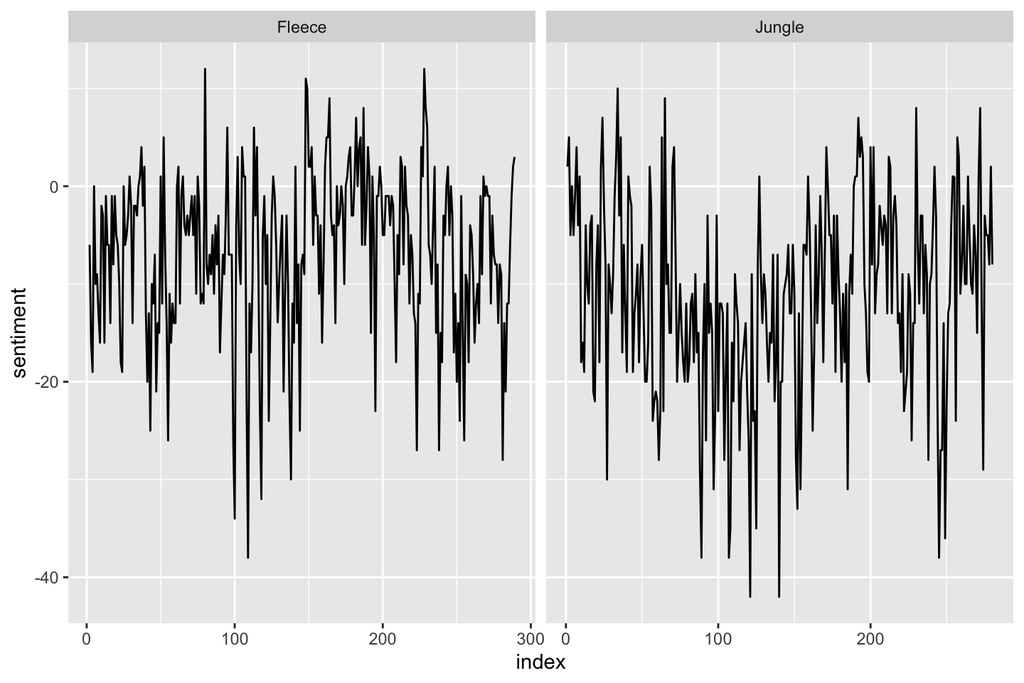

```r
tidy_df |>
  inner_join(get_sentiments("bing"), by = "word") |>
  count(book, index = linenumber %/% 50, sentiment) |>
  pivot_wider(
    names_from = sentiment, values_from = n,
    values_fill = list(n = 0)
  ) |>
  mutate(sentiment = positive - negative) ->
tidy_df_sentiment

tidy_df_sentiment |>
  ggplot(aes(index, sentiment)) +
  geom_line(show.legend = FALSE) +
  facet_wrap(~book, ncol = 2, scales = "free_x") ->plot_line
plot_line
```

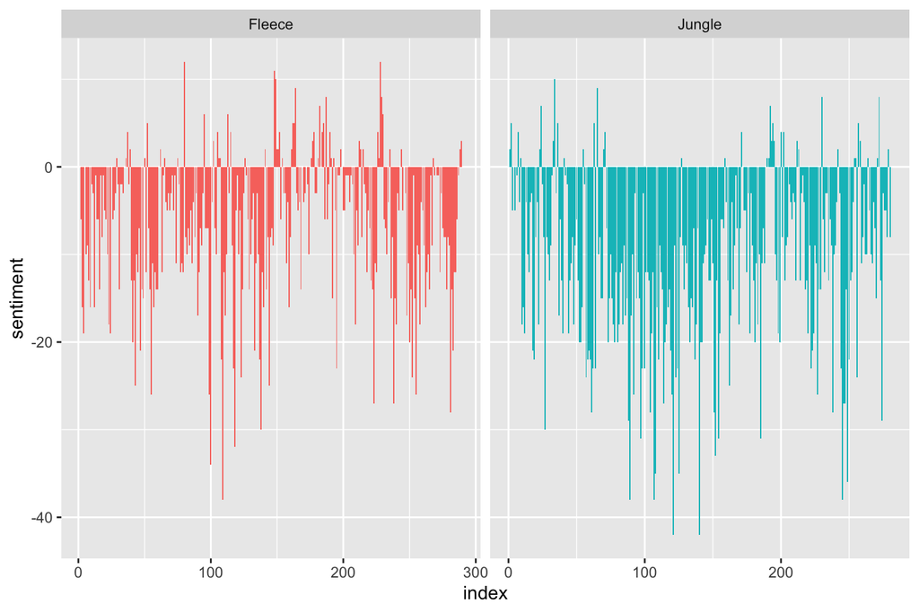

```r
tidy_df_sentiment |>
  ggplot(aes(index, sentiment, fill = book)) +
  geom_col(show.legend = FALSE) +
  facet_wrap(~book, ncol = 2, scales = "free_x") ->plot_col
plot_col
```

The overall sentiment of both books tends to be negative, with each having a peak in sentiment in the middle and later parts. However, compared to The Quest of the Silver Fleece, The Jungle shows a more negative sentiment.

6. Measure the total for each nrc sentiment in each block of **500** lines and then,
- Filter out the “positive” and “negative” and save to a new variable. You should have 464 observations.
- Plot the count of the sentiments for each block in each book in an appropriate faceted plot with the books in two columns and the sentiments in 8 rows.
- Be sure to remove the legend.
- show the plots, they should look like one of the following.
- Interpret the plots for each book and then compare them.
- Why did the values drop off suddenly at the end of Jungle?

```r
tidy_df |>
  inner_join(get_sentiments("nrc"), by = "word") |>
  count(book, index = linenumber %/% 500, sentiment) |>
  filter(!sentiment %in% c("positive", "negative")) ->tidy_df_nrc
nrow(tidy_df_nrc)
```

```
[1] 464
```

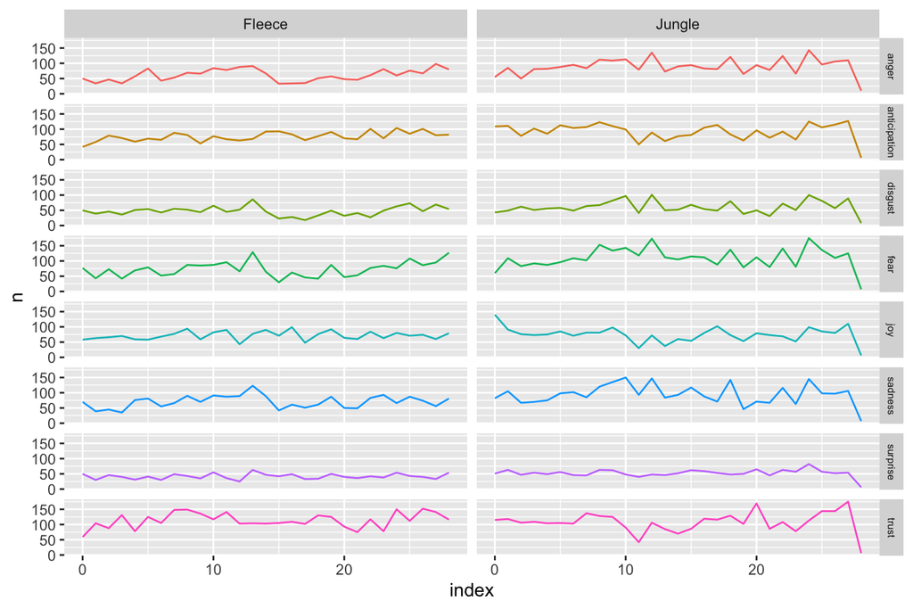

```r
tidy_df_nrc |>
  ggplot(aes(x = index, y = n, color = sentiment)) +
  geom_line(show.legend = FALSE) +
  facet_grid(rows = vars(sentiment), cols = vars(book)) +
  theme(strip.text.y = element_text(size = 6))
```

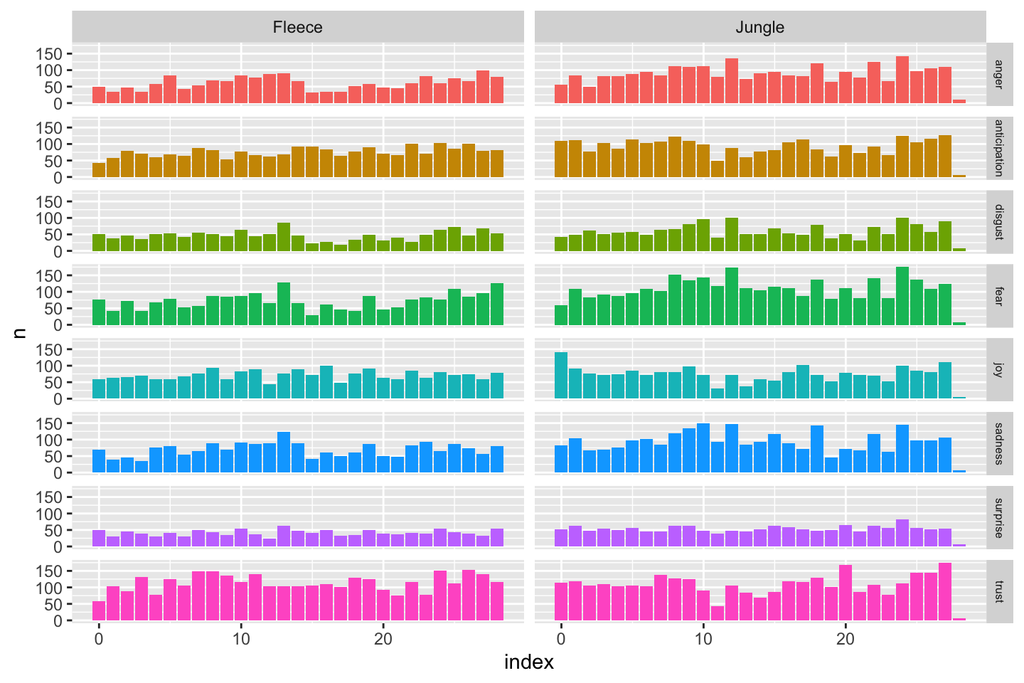

```r
tidy_df_nrc |>
  ggplot(aes(x = index, y = n, fill = sentiment)) +
  geom_col(show.legend = FALSE) +
  facet_grid(rows = vars(sentiment), cols = vars(book)) +
  theme(strip.text.y = element_text(size = 6))
```

In The Quest of the Silver Fleece, the emotions of trust and anticipation are the most prominent, while disgust and surprise are the least expressed.

In The Jungle, fear and trust are the most prominent emotions, while disgust and surprise are the least expressed.

When comparing the two books, The Jungle exhibits more dramatic emotional fluctuations, whereas The Quest of the Silver Fleece has relatively steadier emotions.

The drop in counts at the end of The Jungle is due to the final section containing much fewer than 500 lines, resulting in significantly lower sentiment counts for the last block.

7. Using bing, create a new data frame with the counts of the positive and negative sentiment words for each book.
- Looking across both books, show the “top 20” most frequent words in *a book* along with their book, sentiment, and count, in descending order by count.
- Show the positive words in the list of “top 20”. There should be 4.

```r
tidy_df |>
  inner_join(get_sentiments("bing"), by = "word") |>
  count(book, word, sentiment, sort = TRUE) -> sentiment_counts

sentiment_counts |>
  head(n = 20) -> top_20
top_20
```

```
# A tibble: 20 × 4
   book   word    sentiment     n
   <chr>  <chr>   <chr>     <int>
 1 Fleece miss    negative    467
 2 Fleece slowly  negative    124
 3 Fleece dark    negative     96
 4 Jungle poor    negative     80
 5 Jungle cold    negative     79
 6 Jungle hard    negative     61
 7 Jungle lost    negative     61
 8 Jungle wild    negative     55
 9 Fleece love    positive     54
10 Jungle fell    negative     51
11 Fleece fell    negative     50
12 Fleece mighty  positive     48
13 Jungle death   negative     47
14 Jungle free    positive     44
15 Fleece silent  positive     43
16 Jungle killing negative     43
17 Jungle cry     negative     41
18 Fleece hard    negative     40
19 Jungle agony   negative     40
20 Fleece poor    negative     39
```

```r
top_20 |>
  filter(sentiment == "positive") |>
  nrow()
```

```
[1] 4
```

8. Plot the top ten positive and top ten negative sentiments just for each book, faceting by book and sentiment (total 20 words per book).
- Ensure each facet has the words in the proper order for that book.
- Identify any that may be inappropriate for the context of the book and should be excluded from the sentiment analysis.
- Show the plots. They should look like the following.

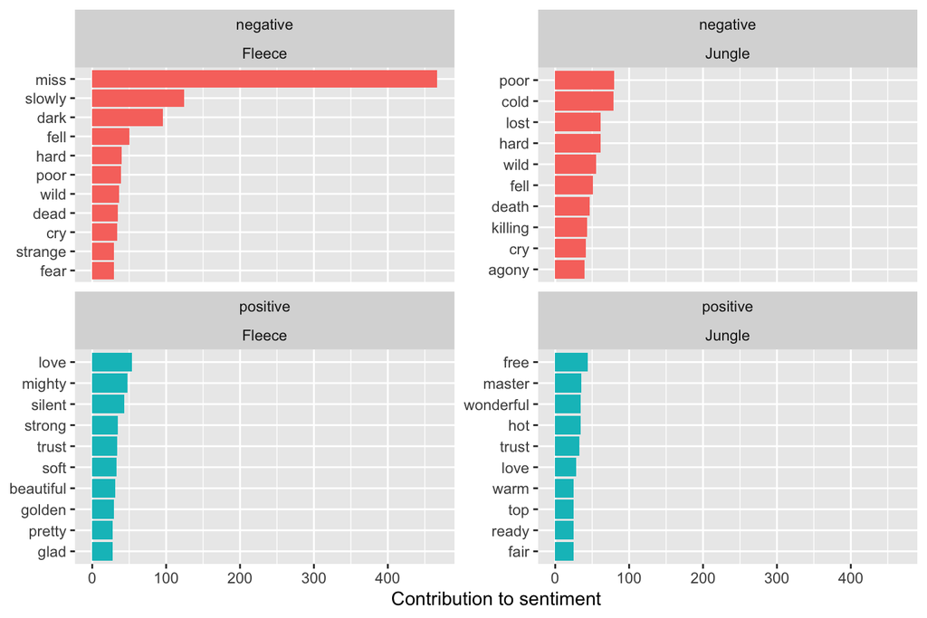

```r
sentiment_counts |>
  group_by(book, sentiment) |>
  slice_max(order_by = n, n = 10) |>
  ungroup() |>
  mutate(word = reorder_within(word, n, book)) |>
  ungroup() |>
  ggplot(aes(word, n, fill = sentiment)) +
  geom_col(show.legend = FALSE) +
  facet_wrap(sentiment ~ book, scales = "free_y") +
  scale_x_reordered() +
  labs(
    y = "Contribution to sentiment",
    x = NULL
  ) +
  coord_flip()
```

In The Quest of the Silver Fleece, “Miss” likely refers to a young woman rather than carrying a negative connotation.

In The Jungle, “hot” most commonly refers to the intense conditions of a harsh environment or emotional tension, so it is unlikely to have a positive meaning.

9. Remove the inappropriate word(s) from the analysis.
- Replot the top 10 for each sentiment per book from step 8 (total 20 words per book).
- Interpret the plots.

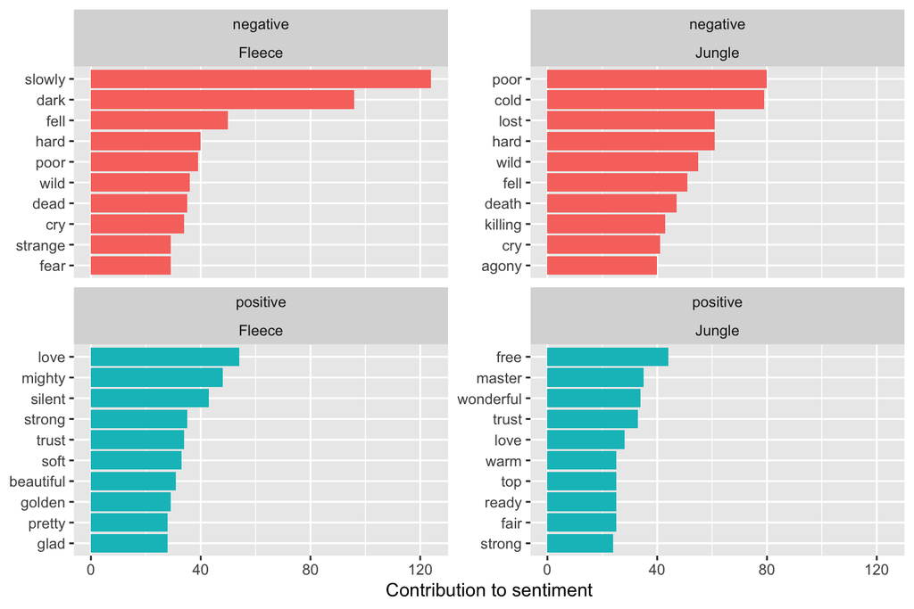

```r
get_sentiments("bing") |>
  filter(word != "miss", word != "hot") ->
bing_edited

tidy_df |>
  inner_join(bing_edited, by = "word") |>
  count(book, word, sentiment, sort = TRUE) ->
sentiment_counts_edited

sentiment_counts_edited |>
  group_by(book, sentiment) |>
  slice_max(order_by = n, n = 10) |>
  ungroup() |>
  mutate(word = reorder_within(word, n, book)) |>
  ungroup() |>
  ggplot(aes(word, n, fill = sentiment)) +
  geom_col(show.legend = FALSE) +
  facet_wrap(sentiment ~ book, scales = "free_y") +
  scale_x_reordered() +
  labs(
    y = "Contribution to sentiment",
    x = NULL
  ) +
  coord_flip()
```

The Quest of the Silver Fleece tells a story of love and struggle centered on African Americans. As a result, “love” is the most frequent positive word in the book. While positive words appear slightly more often than in the other book, negative words still outnumber positive ones overall.

The Jungle is a social critique novel that focuses on the struggles of the working class, exposing the poverty, exploitation, and corruption brought by industrialization. Consequently, negative words occur more frequently than positive ones, with the most common being “poor,” “cold,” “lost,” and “hard,” all closely tied to themes of poverty.

10. Rerun the analysis from step 5 and recreate the plot with the title “Custom Bing”.
- Show both the original step 5 plot with the new plot in the same output graphic, one on top of the other so the books are above each other (in columns) with original in the top row and custom in the second row.
  - It should look like one of the following options.
- Interpret the plots.

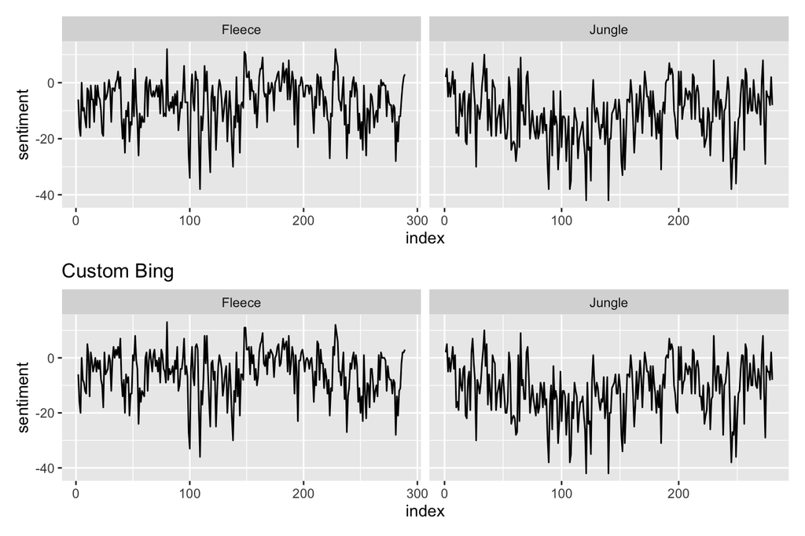

```r
library(patchwork)

tidy_df |>
  inner_join(bing_edited, by = "word") |>
  count(book, index = linenumber %/% 50, sentiment) |>
  pivot_wider(
    names_from = sentiment, values_from = n,
    values_fill = list(n = 0)
  ) |>
  mutate(sentiment = positive - negative) ->
tidy_df_sentiment_edited

tidy_df_sentiment_edited |>
  ggplot(aes(index, sentiment)) +
  geom_line(show.legend = FALSE) +
  facet_wrap(~book, ncol = 2, scales = "free_x") +
  labs(title = "Custom Bing") ->plot_line_edited

tidy_df_sentiment_edited |>
  ggplot(aes(index, sentiment, fill = book)) +
  geom_col(show.legend = FALSE) +
  facet_wrap(~book, ncol = 2, scales = "free_x") +
  labs(title = "Custom Bing") ->plot_col_edited

(plot_line / plot_line_edited)
```

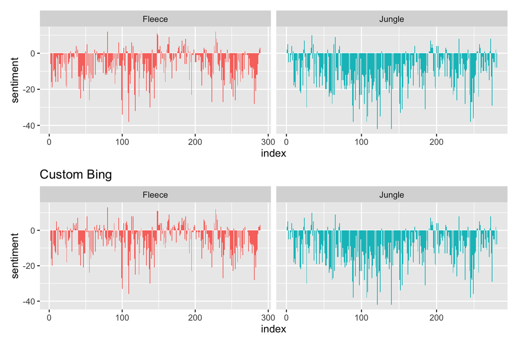

```r
(plot_col / plot_col_edited)
```

From the chart, it can be observed that in the early part of The Quest of the Silver Fleece, the net sentiment in the Custom Bing version is more positive compared to the original version. This could be because the word “Miss” appears more frequently in the earlier part of the story, and after removing it from the negative sentiment words, the net sentiment in the early section becomes more positive.

On the other hand, in The Jungle, the Custom Bing version has fewer positive net sentiment values between the 50th and 70th segments compared to the original. This might be because the word “hot” appears more frequently in this section, and after removing it from the positive sentiment words, the positive net sentiment in this segment decreases.